# Unit 3. Selection on the observables

UAB, 16-18 June, 2021

## A simple example of unconfoundedness

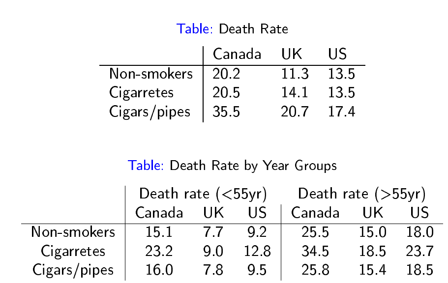

## Unconfoundedness and Controlling for confounders

- Under the **Unconfoundedness** (aka Conditional Independance) assumption

\[ \small \{Y_{i}(1), Y_{i}(0)\} \perp D_i | {X}_i \]

- We block backdoor paths that create noncausal correlations

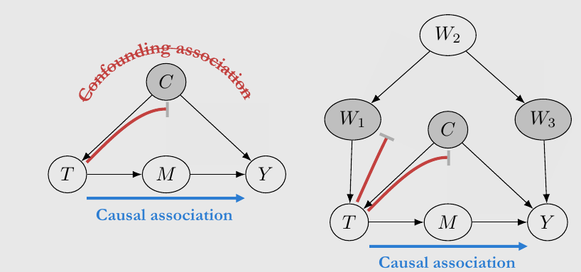

## Identification of conditional ATE and of ATE

- Consider the difference of conditional expectations \[ \small E[Y |{x}, D = 1] - E [Y |{x}, D = 0] = E[Y(1) |{x}, D = 1] - E [Y(0)|{x}, D = 0] \]
- Under unconfoundedness, \[ \small \begin{align*} E[Y(1) |{x}, D = 1] &=E[Y(1) |{x}, D = 0] = E[Y(1) |{x}] \\ E[Y(0) |{x}, D = 1] &=E[Y(0) |{x}, D = 0] = E[Y(0) |{x}] \end{align*} \]
- Hence,

\[ \small \begin{align*} E[Y |{x}, D = 1] - E [Y |{x}, D = 0] &= E[Y(1) |{x}] - E [Y(0)|{x}] \\ &= E[Y(1)-Y(0)|{x}] = ATE({x}) \end{align*} \]

- These conditional expectations, \(E [Y |{x}, D ]\), depend entirely on observables
- Then \(\small ATE= E_X[ATE(X)]\)

## Unconfoundedness and “selection on observables”

- Under uncoundoundedness, we assume that differences between the treated and the control group can be explained by \(\small {x}\)
  - given these characteristics, treatment status is random.
- It implies selection into treatment operates *only* through \(\small {x}\)
  - Either characteristics directly determine participation
  - or individuals with different characteristics have different potential outcomes (which determine participation)

## Unconfoundedness is untestable

- Unconfoundedness is only satisfied when conditioning on *all* the relevant variables
  - So, treated and control individual are really comparable/similar
- Researchers should convince that conditioning on their set of particular characteristics is “enough”
- Note that there are always missing variables, but we are worried about those related to treatment status and potential outcomes.

## Estimation of Treatment Effects

- We will see three “different” approaches to estimate ATE under unconfoundedness
  - Regression
  - Weighting (based on Propensity Score)
  - Matching
- Similarities are more than differences: all of them share main basic assumption, plus other minor ones
- All three types can actually be written as weighting estimators in the literal sense.

## Unconfoundedness and regression

- Under unconfoundedness, it can be prove that

\[ \small E[Y|D, {x}] = \mu_0 + \alpha D + g_0 ({x})+ D[ g_1 ({x})- g_0 ({x})] \]

- Under some *additional* assumptions about parametric functional forms of \(\small g_0 ({x})\) and \(\small g_1 ({x})\), we get the standard (linear) regression model
- These \(\small g_0 ({x})\) and \(\small g_1 ({x})\) are functions that controls for the selection bias
- Under unconfoundedness, selection bias is a “known” function of observables: **selection on observable**

## Propensity Score and the Overlap Assumption

- The propensity score is the probability of treatment given the covariates \({x}\): \[ \small p( {x})= \Pr( D = 1| {X}={x}) \]
- **Overlap (or common support) assumption** \[ \small 0 < p({x}) <1, \quad \forall {x} \in supp({X}) \]
  - Each unit in the defined population has some chance of being treated and some chance of being untreated.
- \(ATT\) is identified with a weaker assumption: \[ \small p({x}) <1, \quad \forall {x} \in supp({X}) \]
  - It can make sense to exclude units that have no chance of being treated: millionaires when evaluating a job training program

## Graphically checking the overlap assumption

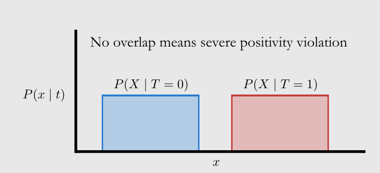

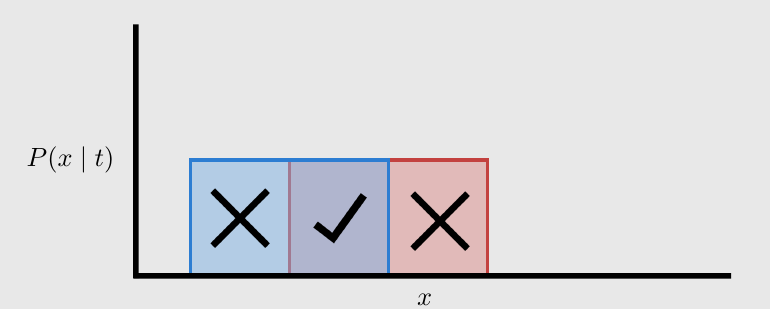

## Graphical checks

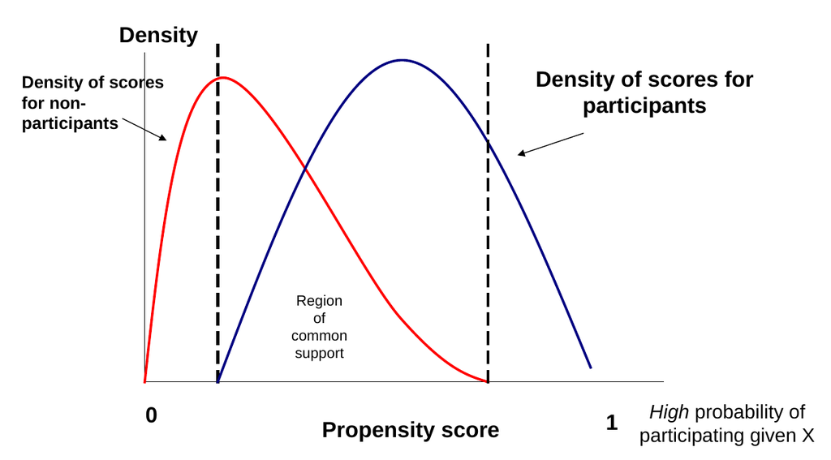

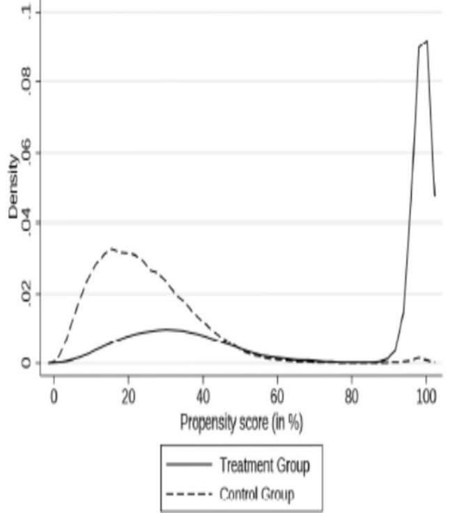

## Comments on the Overlap Assumption

- The parametric linear regression model does not require the common support condition: the functional form fills in (extrapolates) for the data that are missing when this assumption fails to hold
- If common support condition fails we should only be able to identify ATE for the range of values with common support.
- But if we extrapolate using a bad parametric approximation outside the region we can find spurious positive or negative effects…
- This is both part of the charm and part of the horror of the standard parametric approach:

## Extrapolation

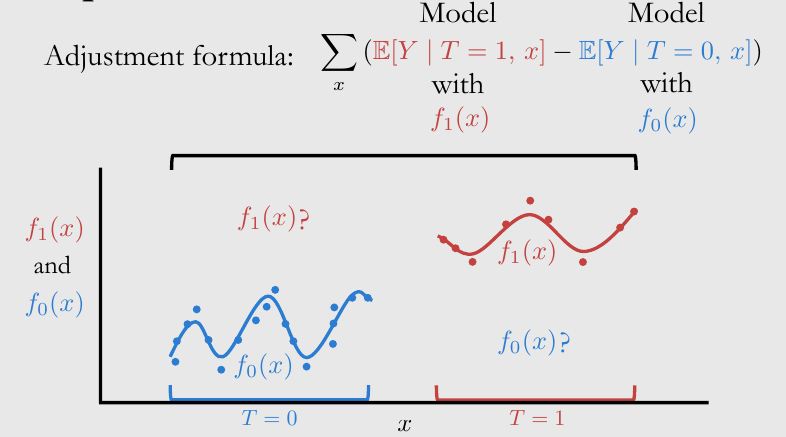

## Extrapolation (cont’d)

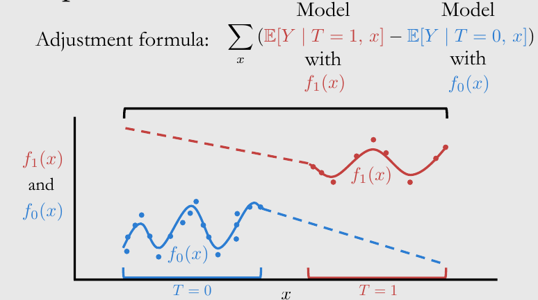

## The Propensity Score Theorem

- By conditioning either on \({x}\) or on the propensity score we get rid of the correlation between potential outcomes and \(D\)

  \[ \small (Y(0), Y(1)) \perp D| {x} \quad \Rightarrow (y_0 , y_1) \perp D| p ({x}) \]
- \(p({x})\) contains all the relevant information in \({x}\) about \(D\), even though it is a particular function of \({x}\) (smaller set)

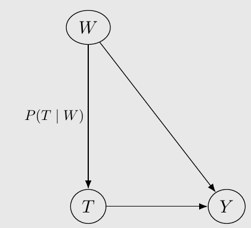

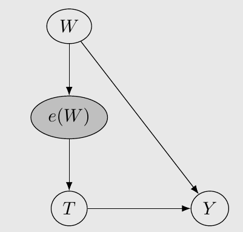

- Implication: overlap decreases with the dimensionality of the adjustment set

## Pseudo-populations

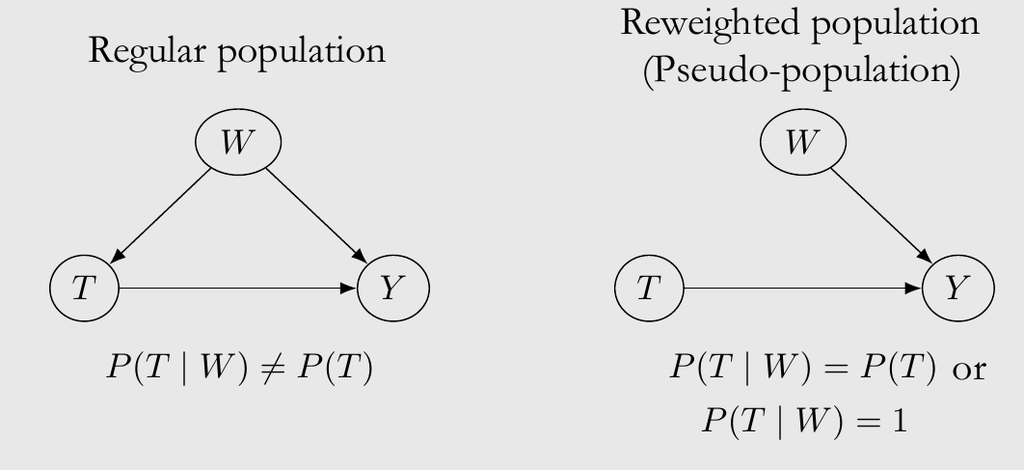

## Inverse Probability Weighting

- Under unconfoundedness and overlap assumptions

\[ \small \begin{aligned} E\left[\frac{DY}{p({x})}\right]-E\left[\frac{(1-D)Y}{(1-p({x}))}\right] &= E \left[\frac{(D-p({x}))Y}{p({x}) (1-p({x}))}\right] = ATE \\ & \\ \frac{1}{\Pr(D=1)}\left(E\left[DY\right]-E\left[\frac{(1-D)Yp({x})}{(1-p({x}))}\right] \right) &=\frac{1}{\Pr(D=1)}E \left[\frac{(D-p({x}))Y}{(1-p({x}))}\right] \\ &= ATT \end{aligned} \]

- We need an estimator of the propensity score \(p({x} )\), eg., using a flexible parametric model \[ \small\widehat{p}({x}) \equiv F({x};\widehat{\gamma}) \]
- Then we obtain consistent estimates of ATE and ATT

## The Balancing Condition

- The propensity score theorem implies that the assignment to treatment is random for individuals with the same propensity score.
- In other words, if their ex-ante probability of treatment is just the same, their actual status can only be explained by random reasons.
- Therefore, individuals with the same propensity score should look, on average, identical in terms of their unobservable and observable characteristics in the treatment and in the control group.
- Note the analogue with experiments: random assignment balanced both observed and unobserved characteristics of the treated and untreated individuals
- Analyses based on propensity scores should report evidence on balance, just as experimental analyses do.

## The Balancing Condition (cont’d)

- The simplest test is to compute the IPW formulae for \(X\) after re-weighting: \(\small \widetilde{X}=\frac{DX}{p({x})}+\frac{(1-D)X}{(1-p({x}))}\)
- Ex.: Kolmogorov-Smirnov test for the distribution of \(\small \widetilde{X}\) (after weighthing), being the same for the treated and the untreated
- A common measure is based on standardized differences: \[ \small StdDiff=\dfrac{\overline{X}_{1W}-\overline{X}_{0W}}{\sqrt{\left(V_{1W}(X)+V_{0W}(X)\right)}} \]
- Also the ratio of variances \(V_{1W}(X)/V_{0W}(X)\) should be one.
- Balance is informative about a potential failure of unconfoundedness (not controlling for all the relevant characteristics), but it may also fails if propensity score specification is not flexible enough.

## Matching

- Matching estimators impute a value on the counterfactual for each unit:
  - Unit \(i\) in the control group: we observe \(Y_{i}(0)\), but need to impute \(Y_{i}(1)\)
  - Unit \(j\) in the treated group: we observe \(Y_{j}(1)\), but need to impute \(Y_{j}(0)\)
- Matching estimators take the general form: \[ \small \widehat{ATE}_{matching} = \frac{1}{n} \sum^n_{i=1} (\widehat{Y}_{i}(1)-\widehat{Y}_{i}(0)) \] \[ \small \widehat{ATET}_{matching} = \frac{1}{n_1} \sum^n_{i=1} D_i(Y_i-\widehat{Y}_{i}(0)) \]
  - Note that \(Y_{i}(1)\) is always observed for the treated subsample (\(D_i = 1\)), so we never need to impute it.

## Matching (cont’d)

- The procedure construct imputations of missing potential outcomes by matching treated and untreated individuals on their observable characteristics \(x\)
- In the discrete case, \(\small \widehat{Y}_{i}(0) = \overline{Y}_0^{j(i)}\equiv \sum_{k\in(D=0)} \frac{1(X_k=X_i)}{\sum_{l\in(D=0)}1(X_l=X_i)}Y_k\)
- In general, \(\small \widehat{Y}_{i}(0) = \sum_{k\in(D=0)} w(i,k) Y_k\)

  (and similarly for \(\widehat{Y}_{i}(1)\))
- Different matching estimators use different weighting schemes.

## Exact and Inexact Matching

- **Exact matching** (or cell matching) is practicable when the vector of covariates is discrete and the sample contains many observations at each distinct value of \({x}_i\)
- If the covariate vector is highly dimensional and/or some covariates are continuous, exact matching becomes impractical: many cells will have no counterfactual observation.
  - “curse of dimensionality” / common support problem.
- **Inexact matching** reduce the dimension of the problem by defining a distance metric on \({x}\) and then matching using the scalar distance \(D({x})\) rather than the vector \({x}\).
- Asymptotically (and under common support assumption), all inexact matching schemes are equivalent (in large sample, one has only exact matches). But they can yield very different answers in finite samples.

## How to Match: Single Match for each observation

- The simplest approach to find a match (Abadie and Imbens, 2006) is a **single match** for each observation
- If \(i\) is a treated unit (\(D_i=1\)), then \(\widehat{y}_{1,i}=Y_i\) and \(\widehat{Y}_{i}(0)=Y_h\)
  - such that \(D_h = 0\)
  - and unit \(h\) is “closest” to unit \(i\) based on some metric (distance) in the covariates (\(x_h\) is “closest” to \(x_i\))
- For the treated unit \(i\) we find the “most similar” untreated observation \(h\) and use its response as \(Y_{i}(0)\)
- Procedure is similar if \(i\) is a control unit (\(D_i=0\))

## How to Match: Single Match for each observation (cont’d)

- Note that the nearest neighbor can be not very similar due to a failure of the common support condition or due to small sample size.
- The balance condition after match can be checked (ex.: the distribution of characteristics for the treated individuals and their matches should be similar (“common support”))
- The most popular metrics for distance the between observations \(i\) and \(j\) are the Mahalanobis metric: \[d_M ({x}_i, {x}_j) = ({x}_i - {x}_j )' \Sigma^{-1}_{{x}} ({x}_i - {x}_j )\]
  - where \(\Sigma_{{x}}\) is the covariance matrix of the covariates

## Example

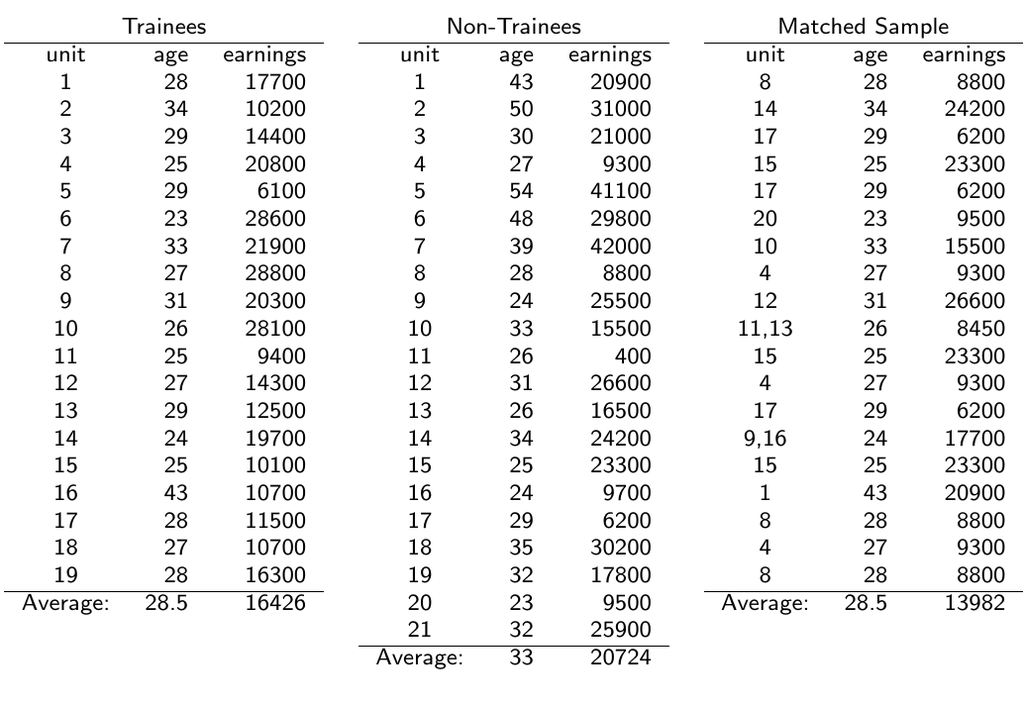

## Example: age distribution before

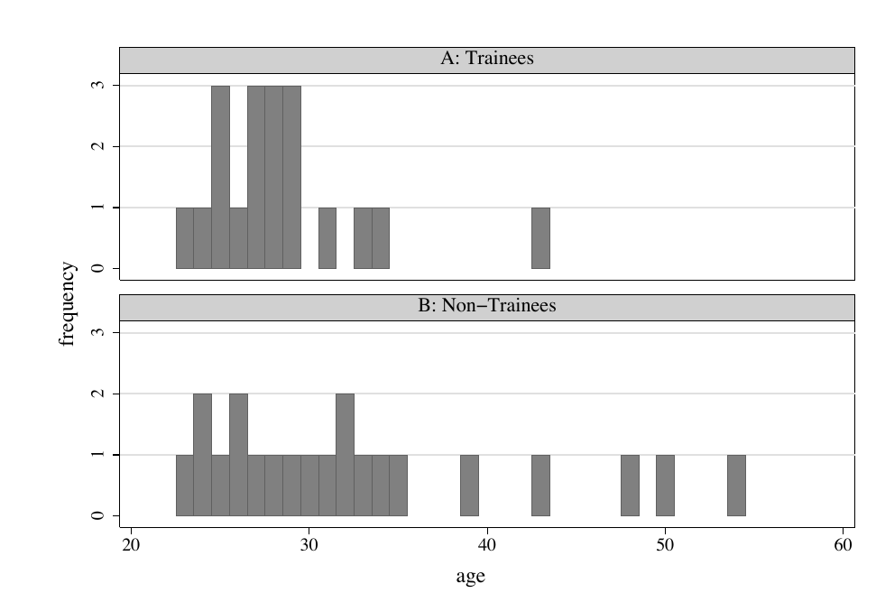

## Example: age distribution after

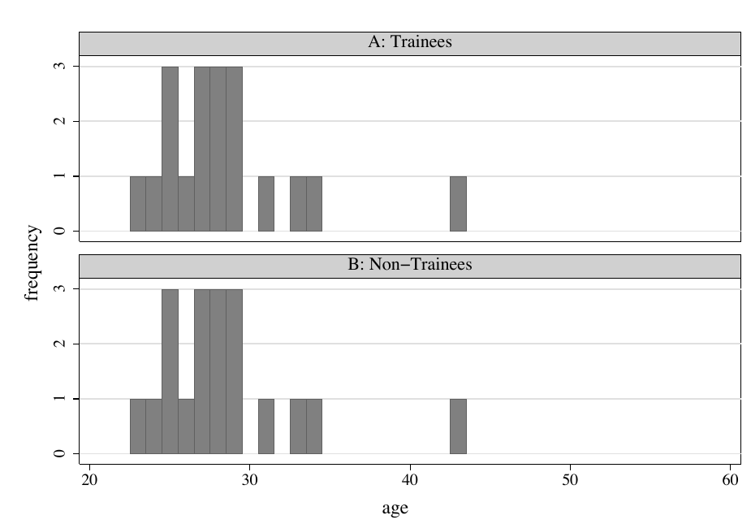

## How to Match: Several neighbors

- More generally, we can impute the missing value using an average of \(M\) nearest neighbors
- If \(i\) is a treated unit (\(D_i=1\)), then \[ \small \widehat{Y}_{i}(1)=Y_i\] and \[\small \widehat{Y}_{i}(0)=\frac{1}{M}\sum_{h\in A^U_M(i) }Y_h\]
  - where \(A^U_M(i)\) contains \(M\) untreated nearest matches to observation \(i\), based on the covariates
  - so \(D_h = 0,\quad \forall h\in A^U_M(i)\)

## Matching on the Propensity Score

- Matching on the propensity score is computationally easier because it is a single variable with range in \((0, 1)\)
- Intuition: we estimate the counterfactual of individual \(i\) using individual(s) that are similar terms of the propensity score.
- Why is this appealing?
  - Suppose we select two individuals with the same propensity score: *ex-ante* they have the same likelihood of treatment
  - One receives treatment and the second does not: *ex-post* assignment to treatment can be regarded as “random”
- Note the importance of Overlapping: we need common support of characteristics for the treated and control individuals

## Variations on matching

- Bias-corrected matching (using regression), Abadie and Imbens (2011)
- Multi-treatment matching (many pairwise comparisons)
- Matching for continuous treatments (i.e. dose-response: how to discretize the treatment?)
- Difference-in-differences matching, controlling semi-parametrically for covariates
- Estimators that enforce balancing: genetic matching, coarsened exact matching, [entropy balance](https://web.stanford.edu/~jhain/software.htm)